# Stat 243 – Final Exam

May 18, 2020

### Problem 2.A

```r
birds <- read.csv('https://sldr.netlify.app/data/birds2.csv')
# This finds the difference between the mean of Passeriformes fid.relative.change and Columbiformes' fid.relative.change; it does this 1000 times and resamples the data to create a bootstrap distribution
boots <- do(1000) * diff(mean(~fid.relative.change | order, data=resample(birds)))

# The sample statistic is the mean of differences between the orders (types) of birds
# The "Passeriformes" variable is really the difference between the two types of birds
sample_statistic <- mean(~Passeriformes, data=boots)
sample_statistic
```

```
## [1] -0.2682872
```

### Problem 2.B

```r
# sd is used to find the standard error for the variable Passeriformes (which is really the difference of Passeriformes minus Columbiformes) from the data boots
SE <- sd(~Passeriformes, data=boots)

# The confidence interval is the sample statistic +/- 2 * standard error
CI <- sample_statistic + c(-1,1)*2*SE
CI
```

```
## [1] -0.3983454 -0.1382290
```

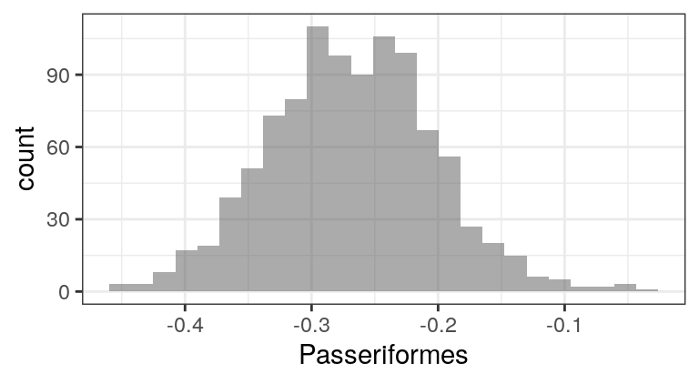

```r
gf_histogram(~Passeriformes, data=boots)
```

### Problem 2.C

Done in code for Problem 2.A and 2.B

### Problem 3.A

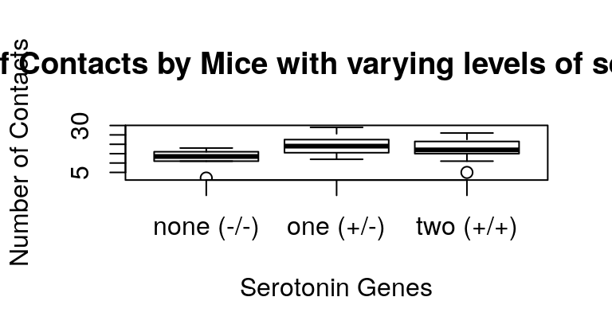

```r
mice <- read.csv('https://sldr.netlify.app/data/mice.csv')
boxplot(n_contacts ~ serotonin_genes, data=mice, main="Number of Contacts by Mice with varying levels of serotinin genes", xlab="Serotonin Genes", ylab="Number of Contacts")
```

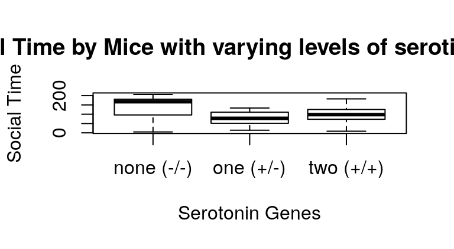

```r
boxplot(social_time ~ serotonin_genes, data=mice, main="Social Time by Mice with varying levels of serotinin genes", xlab="Serotonin Genes", ylab="Social Time")
```

I chose to include basic boxplots instead without the bars. This makes it easier to compare more accurately the distributions between the different genotypes and how those differences are reflected in social time and number of contacts. With boxplots, one can see a better picture of each distributions median, quartiles and etc.

### Problem 3.B

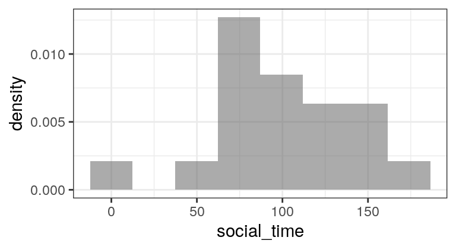

```r
gf_dhistogram(~social_time, data=mice[ mice$serotonin_genes=="two (+/+)", ], bins=8)
```

The graph seems to be right skewed, with the median around 90-100.

### Problem 3.C

```r
two_data <- mice[ mice$serotonin_genes=="two (+/+)", ]
head(two_data)
```

```
##    social_time n_contacts    sex serotonin_genes
## 2         73.9         23   male       two (+/+)
## 4         68.6         15 female       two (+/+)
## 9         72.0         15   male       two (+/+)
## 10        92.0         19   male       two (+/+)
## 11       102.9         20   male       two (+/+)
## 14       111.5         25   male       two (+/+)
```

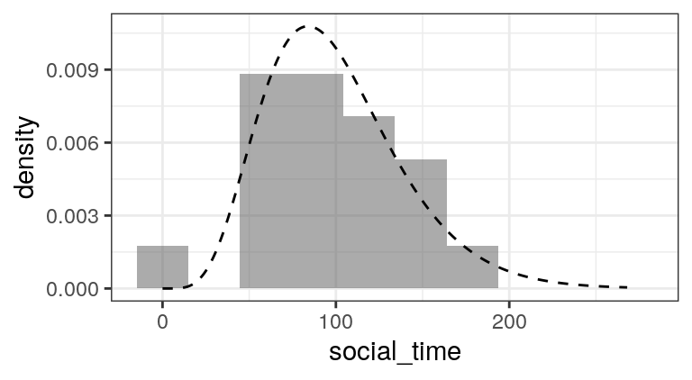

```r
social_mean <- mean(~social_time, data=two_data)
social_var <- sd(~social_time, data=two_data)^2
beta <- social_var/social_mean
alpha <- social_var/(beta*beta)
gf_dhistogram(~social_time, data=two_data, bins=10) %>%
gf_dist('gamma', params = list(shape = alpha, scale=beta), linetype='dashed')
```

#### Gamma Distribution Method of Moments

$mean = α*β$

$variance = α*β^{2}$

$mean = 99.71$

$variance = 1576.35$

#### Solving

$α = \frac{variance}{β^{2}}$

$mean = \frac{variance}{β^{2}}*β$

$mean = \frac{variance}{β}$

$β = \frac{variance}{mean}$

#### Parameters

$β = 15.8100812$

$α = 6.3064359$

#### Quality of Fit

The fit is roughly able to portray the data, its skew, and the median. I think it might do better to be steeper on the left hand side and less steep on the right hand side. But, overall, it does a great job.

### Problem 3.D

#### ANOVA Test

```r
car::Anova(lm(social_time ~ serotonin_genes, data = mice))
```

```
## Anova Table (Type II tests)
##
## Response: social_time
##                 Sum Sq Df F value   Pr(>F)
## serotonin_genes  22083  2  5.6569 0.006433 **
## Residuals        87832 45
## ---
## Signif. codes:  0 '***' 0.001 '**' 0.01 '*' 0.05 '.' 0.1 ' ' 1
```

The first hypothesis test is to determine whether or not there is a difference between the three genotypes. We use an ANOVA test to do this. The anova function has a hypothesis test that the differences are all the same, and the given p-value is the probability of seeing an F Value (our sample statistic for this step) as high as we got if the null hypothesis is true. Therefore, our low p-value of 0.00643 shows there is reason to reject the null hypothesis and continue with TukeyHSD tests.

#### TukeyHSD

```r
TukeyHSD(lm(social_time ~ serotonin_genes, data = mice),
         conf.level = 0.95)
```

```
##   Tukey multiple comparisons of means
##     95% family-wise confidence level
##
## Fit: aov(formula = x)
##
## $serotonin_genes
##                           diff       lwr        upr     p adj
## one (+/-)-none (-/-) -58.03842 -99.87020 -16.206638 0.0044337
## two (+/+)-none (-/-) -36.94474 -78.77652   4.887047 0.0930626
## two (+/+)-one (+/-)   21.09368 -13.64572  55.833089 0.3139957
```

The sample statistic for the difference between one and no genes is -58.0 (conf interval is -99.87020 -16.206638), the difference between two and none is -36.9 (conf interval is -78.77652 4.887047), and the difference between two and one is 21.0 (conf interval: -13.64572 55.833089). The corresponding p-values respectively are 0.004, 0.093, and 0.314. This gives us reason to believe that the mice without either genes (none (-/-)) spend more time with mice than the mice with only one gene. This is because the p-value of the difference between the mice with one and none is very low .004. The other pairs cannot be said to be different due to their large p-values. The mice with one genotype and the mice without any were different by -58.04 with a confidence interval ranging from -99.9 to -16.2. The p-value that states the probability of getting this difference if the two groups of mice were no different is 0.004 which is low enough to reject the null hypothesis that they are not different. Therefore, the pair is different.

### Problem 3.E

#### Conditions

```r
my_model <- lm(n_contacts ~ social_time, data=mice)

my_data <- mice %>% mutate(preds = predict(my_model), resids=resid(my_model))
```

##### Checking Linearity

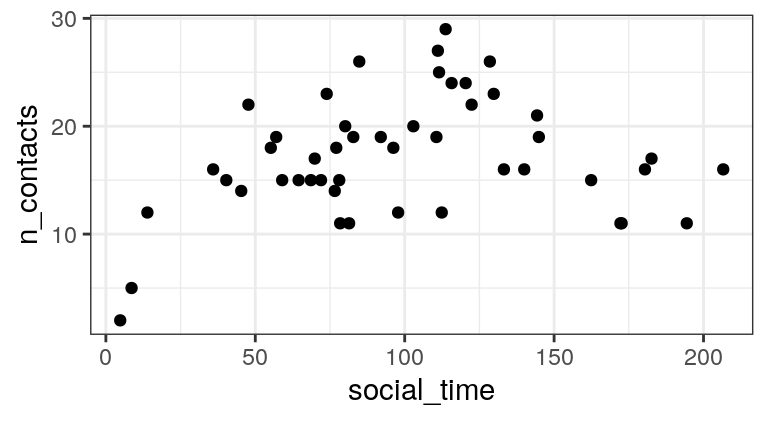

```r
gf_point(n_contacts ~ social_time, data=mice)
```

##### Checking Independence

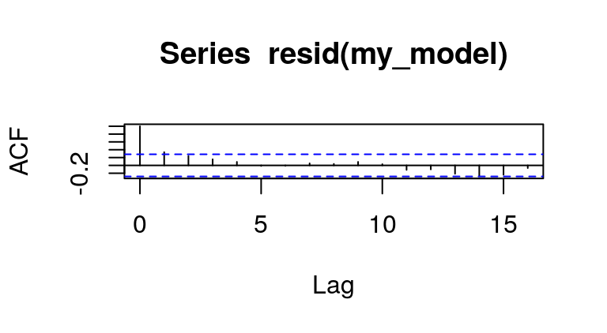

```r
acf(resid(my_model))
```

The data seems to not have any correlations between the residuals (residuals are not affected by past residuals)

##### Checking Constant Variance

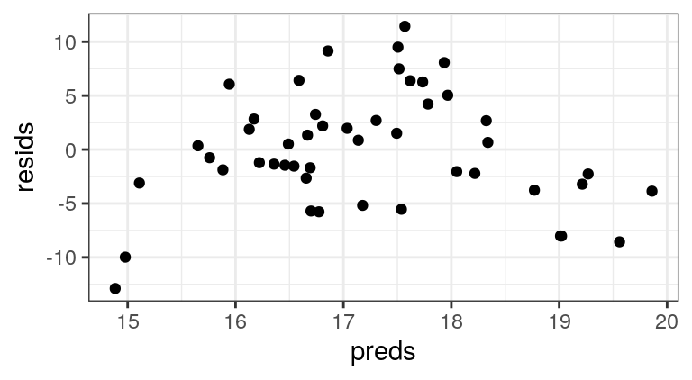

```r
gf_point(resids ~ preds, data=my_data)
```

Looks like there is no obvious correlation between predicted values and the density of the points.

##### Checking normality of residuals

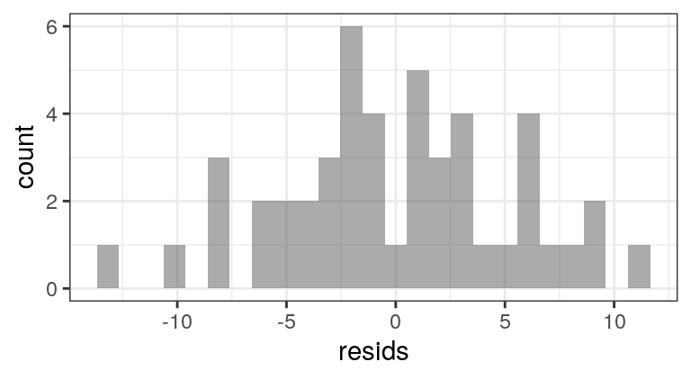

```r
gf_histogram(~resids, data=my_data)
```

Looks roughly normal.

#### Hypotheses

The null hypothesis is that there is no correlation between time spent socializing and the number of contacts (slope=0), while the alternative hypothesis proposes the slope of the fitted line is not 0.

#### Sample Statistic

```r
summary(my_model)
```

```
##
## Call:
## lm(formula = n_contacts ~ social_time, data = mice)
##
## Residuals:
##      Min       1Q   Median       3Q      Max
## -12.8845  -3.1351  -0.2055   2.9361  11.4305
##
## Coefficients:
##             Estimate Std. Error t value Pr(>|t|)
## (Intercept) 14.76614    1.79959   8.205 1.48e-10 ***
## social_time  0.02466    0.01636   1.507    0.139
## ---
## Signif. codes:  0 '***' 0.001 '**' 0.01 '*' 0.05 '.' 0.1 ' ' 1
##
## Residual standard error: 5.424 on 46 degrees of freedom
## Multiple R-squared:  0.04706,    Adjusted R-squared:  0.02634
## F-statistic: 2.272 on 1 and 46 DF,  p-value: 0.1386
```

The sample statistic is the slope equals 0.024 with standard error 0.016. The p-value is high (0.139), so we cannot reject the null hypothesis, meaning for all we know the time spent socializing probably does not predict the number of contacts.

### Problem 4.A

This was an observational experiment, with a sampling scheme of a convience sampling. The reason it is convience sampling is that even though the study aims to make conclusions about the US healthcare in general, it only seems to do hospitals in the New York region, which I assume is where the researchers are able to their work easier considering the amount of people in New York with the disease.

### Problem 4.B

The population parameter of interest is the mortality rate of COVID-19. The population of interest is stated to be the people in the U.S. Healthcare system. A reasonable population would be the people in the New York region, considering the samples were from there.

### Problem 4.C

```r
n <- 282+38
p <- 282 / n
se <- sqrt(p*(1-p)/n)
z <- 1.96 #95% confidence z score
conf <- p+c(-1, 1)*se*2
conf
```

```
## [1] 0.8450823 0.9174177
```

The confidence interval ranges from 0.84 to 0.91.

### Problem 4.D

```r
n <- 282+831+38
p <- 282 / n
se <- sqrt(p*(1-p)/n)
z <- 1.96 #95% confidence z score
conf <- p+c(-1, 1)*se*2
conf
```

```
## [1] 0.2196501 0.2703586
```

If the people who at the time of recording survived, the new confidence interval would be 0.22 to 0.27.

### Problem 4.E

I don’t know why they did it. They could have good intentions, such as trying to convince people that COVID-19 is a big deal, or they could have just wanted publicity. Actually, they might have been pressured by the public to make conclusions very quickly, so that people would at least feel like they know something instead of being told to wait 2-3 weeks before they can definitely say what the mortality rate is. However, I do believe what they did was wrong. They deceived people, causing a panic, which caused significant problems of shortages.